# CAGEr: an R package for CAGE (Cap Analysis of Gene Expression) data analysis and promoterome mining

Vanja Haberle and Charles Plessy

1 November 2022

#### Package

CAGEr 2.4.0

# 1 Introduction

This document briefly how to use *CAGEr* *CAGEr*, a Bioconductor package designed to process, analyse and visualise Cap Analysis of Gene Expression (CAGE)sequencing data. CAGE (Kodzius et al. 2006) is a high-throughput method for transcriptome analysis that utilizes *cap trapping* (Carninci et al. 1996), a technique based on the biotinylation of the 7-methylguanosine cap of Pol II transcripts, to pulldown the 5′-complete cDNAs reversely transcribed from the captured transcripts. A linker sequence is ligated to the 5′ end of the cDNA and a specific restriction enzyme is used to cleave off a short fragment from the 5′ end. Resulting fragments are then amplified and sequenced using massive parallel high-throughput sequencing technology, which results in a large number of short sequenced tags that can be mapped back to the referent genome to infer the exact position of the transcription start sites (TSSs) used for transcription of captured RNAs (Figure 1). The number of CAGE tags supporting each TSS gives the information on the relative frequency of its usage and can be used as a measure of expression from that specific TSS. Thus, CAGE provides information on two aspects of capped transcriptome: genome-wide 1bp-resolution map of TSSs and transcript expression levels. This information can be used for various analyses, from 5′ centered expression profiling (Takahashi et al. 2012) to studying promoter architecture (Carninci et al. 2006).

[figure not shown]

Figure 1: Overview of CAGE experiment

CAGE samples derived from various organisms (genomes) can be analysed by *CAGEr* and the only limitation is the availability of the referent genome as a *BSgenome* package in case when raw mapped CAGE tags are processed. *CAGEr* provides a comprehensive workflow that starts from mapped CAGE tags and includes reconstruction of TSSs and promoters and their visualisation, as well as more specialized downstream analyses like promoter width, expression profiling and differential TSS usage. It can use both Binary Sequence Alignment Map (BAM) files of aligned CAGE tags or files with genomic locations of TSSs and number of supporting CAGE tags as input. If BAM files are provided *CAGEr* constructs TSSs from aligned CAGE tags and counts the number of tags supporting each TSS, while allowing filtering out low-quality tags and removing technology-specific bias. It further performs normalization of raw CAGE tag count, clustering of TSSs into tag clusters (TC) and their aggregation across multiple CAGE experiments into promoters to construct the promoterome. Various methods for normalization and clustering of TSSs are supported. Exporting data into different types of track objects allows export and various visualisations of TSSs and clusters (promoters) in the UCSC Genome Browser, which facilitate generation of hypotheses. *CAGEr* manipulates multiple CAGE experiments at once and performs analyses across datasets, including expression profiling and detection of differential TSS usage (promoter shifting). Multicore option for parallel processing is supported on Unix-like platforms, which significantly reduces computing time.

Here are some of the functionalities provided in this package:

- Reading in multiple CAGE datasets from various sources; user provided BAM or TSS input files, public CAGE datasets from accompanying data package.
- Correcting systematic G nucleotide addition bias at the 5′ end of CAGE tags.
- Plotting pairwise scatter plots, calculating correlation between datasets and merging datasets.
- Normalizing raw CAGE tag count: simple tag per million (tpm) or power-law based normalization (Balwierz et al. 2009).
- Clustering individual TSSs into tag clusters (TCs) and aggregating clusters across multiple CAGE datasets to create a set of consensus promoters.
- Making bedGraph or BED files of individual TSSs or clusters for visualisation in the genome browser.
- Expression clustering of individual TSSs or consensus promoters into distinct expression profiles using common clustering algorithms.
- Calculating promoter width based on the cumulative distribution of CAGE signal along the promoter.
- Scoring and statistically testing differential TSS usage (promoter shifting) and detecting promoters that shift between two samples.

For further details on the implemented methods and for citing the *CAGEr* package in your work please refer to (Haberle et al. 2015).

# 2 Input data for *CAGEr*

The type and the format of the input files is specified at the beginning of the workflow, when the `CAGEset` object is created (section 4.2). This is done by setting the `inputFilesType` argument, which accepts the following self-explanatory options referring to formats mentioned above: `"bam", "bamPairedEnd", "bed", "ctss", "CTSStable"`.

# 3 The *CAGEr* workflow

## 3.1 Getting started

We start the workflow by creating a *CAGEexp* object, which is a container for storing CAGE datasets and all the results that will be generated by applying specific functions. The *CAGEexp* objects are an extension of the *MultiAssayExperiment* class, and therefore can use all their methods. The expression data is stored in *CAGEexp* using *SummarizedExperiment* objects, and can also access their methods.

To load the *CAGEr* package and the other libraries into your R envirnoment type:

```r
library(CAGEr)
```

## 3.2 Creating a *CAGEexp* object

### 3.2.1 Specifying a genome assembly

In this tutorial we will be using data from zebrafish *Danio rerio* that was mapped to the `danRer7` assembly of the genome. Therefore, the corresponding genome package *BSgenome.Drerio.UCSC.danRer7* has to be installed. It will be automatically loaded by *CAGEr* commands when needed.

In case the data is mapped to a genome that is not readily available through *BSgenome* package (not in the list returned by `BSgenome::available.genomes()` function), a custom *BSgenome* package has to be build and installed first. (See the vignette within the *BSgenome* package for instructions on how to build a custom genome package). The `genomeName` argument can then be set to the name of the build genome package when creating a `CAGEexp` object (see the section *Creating `CAGEexp` object* below).

The *BSgenome* package is used to access information about the chromosomes (sequence, length, circularity). By default, *CAGEr* will discard alignments that are not on chromosomes named in the *BSgenome* package. The `genomeName` argument can be set to `NULL` in order to suppress this behaviour, or as a last resort when no *BSgenome* package is available. However, *CAGEr* functions that need access to the genome sequence, for instance for *G-correction* will not work in that case.

### 3.2.2 Specifying input files

The subset of zebrafish (*Danio rerio*) developmental time-series CAGE data generated by (Nepal et al. 2013) will be used in the following demonstration of the *CAGEr* workflow.

```r
inputFiles = list.files( system.file("extdata", package = "CAGEr")
                       , "ctss$"
                       , full.names = TRUE)
```

### 3.2.3 Creating the object

The *CAGEexp* object is crated with the `CAGEexp` contstructor, that requries information on file path an type, sample names and reference genome name.

```r
ce <- CAGEexp( genomeName     = "BSgenome.Drerio.UCSC.danRer7"
             , inputFiles     = inputFiles
             , inputFilesType = "ctss"
             , sampleLabels   = sub( ".chr17.ctss", "", basename(inputFiles))
)
```

To display the created object type:

```r
ce
```

```
## A CAGEexp object of 0 listed
##  experiments with no user-defined names and respective classes.
##  Containing an ExperimentList class object of length 0:
##  Functionality:
##  experiments() - obtain the ExperimentList instance
##  colData() - the primary/phenotype DataFrame
##  sampleMap() - the sample coordination DataFrame
##  `$`, `[`, `[[` - extract colData columns, subset, or experiment
##  *Format() - convert into a long or wide DataFrame
##  assays() - convert ExperimentList to a SimpleList of matrices
##  exportClass() - save data to flat files
```

## 3.3 Reading in the data

In case when the CAGE / TSS data is to be read from input files, an empty *CAGEexp* object with information about the files is first created as described above in section 3.2. To actually read in the data into the object we use `getCTSS()` function, that will add an experiment called `tagCountMatrix` to the *CAGEexp* object.

```r
ce <- getCTSS(ce)
ce
```

```
## A CAGEexp object of 1 listed
##  experiment with a user-defined name and respective class.
##  Containing an ExperimentList class object of length 1:
##  [1] tagCountMatrix: RangedSummarizedExperiment with 23343 rows and 5 columns
## Functionality:
##  experiments() - obtain the ExperimentList instance
##  colData() - the primary/phenotype DataFrame
##  sampleMap() - the sample coordination DataFrame
##  `$`, `[`, `[[` - extract colData columns, subset, or experiment
##  *Format() - convert into a long or wide DataFrame
##  assays() - convert ExperimentList to a SimpleList of matrices
##  exportClass() - save data to flat files
```

This function reads the provided files in the order they were specified in the `inputFiles` argument. It creates a single set of all TSSs detected across all input datasets (union of TSSs) and a table with counts of CAGE tags supporting each TSS in every dataset. (Note that in case when a *CAGEr* object is created by coercion from an existing expression table there is no need to call `getCTSS()`).

Genomic coordinates of all TSSs and numbers of supporting CAGE tags in every input sample can be retrieved using the `CTSStagCountSE()` function. `CTSScoordinatesGR()` accesses the CTSS coordinates and `CTSStagCountDF()` accesses the CTSS expression values.

Data can also be accessed directly using the native methods of the `MultiAssayExperiment` and `SummarizedExperiment` classes, for example `ce[["tagCountMatrix"]]`, `rowRanges(ce[["tagCountMatrix"]])` and `assay(ce[["tagCountMatrix"]])`.

```r
CTSStagCountSE(ce)
```

```
## class: RangedSummarizedExperiment
## dim: 23343 5
## metadata(0):
## assays(1): counts
## rownames: NULL
## rowData names(0):
## colnames(5): Zf.30p.dome Zf.high Zf.prim6.rep1 Zf.prim6.rep2
##   Zf.unfertilized.egg
## colData names(0):
```

```r
CTSScoordinatesGR(ce)
```

```
## CTSS object with 23343 positions and 0 metadata columns:
##           seqnames       pos strand
##              <Rle> <integer>  <Rle>
##       [1]    chr17  26027430      +
##       [2]    chr17  26050540      +
##       [3]    chr17  26118088      +
##       [4]    chr17  26142853      +
##       [5]    chr17  26166954      +
##       ...      ...       ...    ...
##   [23339]    chr17  45975041      -
##   [23340]    chr17  45975540      -
##   [23341]    chr17  45975544      -
##   [23342]    chr17  45982697      -
##   [23343]    chr17  45999921      -
##   -------
##   seqinfo: 26 sequences (1 circular) from danRer7 genome
##   BSgenome name: BSgenome.Drerio.UCSC.danRer7
```

```r
CTSStagCountDF(ce)
```

```
## DataFrame with 23343 rows and 5 columns
##       Zf.30p.dome Zf.high Zf.prim6.rep1 Zf.prim6.rep2 Zf.unfertilized.egg
##             <Rle>   <Rle>         <Rle>         <Rle>               <Rle>
## 1               0       0             1             0                   0
## 2               0       0             0             0                   1
## 3               0       0             1             0                   0
## 4               0       0             0             1                   0
## 5               0       0             1             0                   0
## ...           ...     ...           ...           ...                 ...
## 23339           1       0             0             0                   0
## 23340           0       2             0             0                   0
## 23341           0       1             0             0                   0
## 23342           0       0             1             0                   0
## 23343           1       0             0             0                   0
```

```r
CTSStagCountGR(ce, 1)  # GRanges for one sample with expression count.
```

```
## CTSS object with 7277 positions and 1 metadata column:
##          seqnames       pos strand | score
##             <Rle> <integer>  <Rle> | <Rle>
##      [1]    chr17  26222417      + |     1
##      [2]    chr17  26323229      + |     1
##      [3]    chr17  26453603      + |     2
##      [4]    chr17  26453615      + |     1
##      [5]    chr17  26453632      + |     3
##      ...      ...       ...    ... .   ...
##   [7273]    chr17  45901810      - |     1
##   [7274]    chr17  45901814      - |     1
##   [7275]    chr17  45901816      - |     1
##   [7276]    chr17  45975041      - |     1
##   [7277]    chr17  45999921      - |     1
##   -------
##   seqinfo: 26 sequences (1 circular) from danRer7 genome
##   BSgenome name: BSgenome.Drerio.UCSC.danRer7
```

Note that the samples are ordered in the way they were supplied when creating the *CAGEexp* object and will be presented in that order in all the results and plots. To check sample labels and their ordering type:

```r
sampleLabels(ce)
```

```
##               #FF0000               #CCFF00               #00FF66
##         "Zf.30p.dome"             "Zf.high"       "Zf.prim6.rep1"
##               #0066FF               #CC00FF
##       "Zf.prim6.rep2" "Zf.unfertilized.egg"
```

In addition, a colour is assigned to each sample, which is consistently used to depict that sample in all the plots. By default a rainbow palette of colours is used and the hexadecimal format of the assigned colours can be seen as names attribute of sample labels shown above. The colours can be changed to taste at any point in the workflow using the `setColors()` function.

## 3.4 Quality controls and preliminary analyses

### 3.4.1 Genome annotations

By design, CAGE tags map transcription start sites and therefore detect promoters. Quantitatively, the proportion of tags that map to promoter regions will depend both on the quality of the libraries and the quality of the genome annotation, which may be incomplete. Nevertheless, strong variations between libraries prepared in the same experiment may be used for quality controls.

*CAGEr* can intersect CTSSes with reference transcript models and annotate them with the name(s) of the models, and the region categories *promoter*, *exon*, *intron* and *unknown*, by using the `annotateCTSS` function. The reference models can be GENCODE loaded with the `import.gff` function of the *rtracklayer* package, or any other input that has the same structure, see `help("annotateCTSS")` for details. In this example, we will use a sample annotation for zebrafish (see `help("exampleZv9_annot")`).

```r
ce <- annotateCTSS(ce, exampleZv9_annot)
```

The annotation results are stored as tag counts in the sample metadata, and as new columns in the CTSS genomic ranges

```r
colData(ce)[,c("librarySizes", "promoter", "exon", "intron", "unknown")]
```

```
## DataFrame with 5 rows and 5 columns
##                     librarySizes  promoter      exon    intron   unknown
##                        <integer> <integer> <integer> <integer> <integer>
## Zf.30p.dome                41814     37843      2352       594      1025
## Zf.high                    45910     41671      2848       419       972
## Zf.prim6.rep1              34053     29531      2714       937       871
## Zf.prim6.rep2              34947     30799      2320       834       994
## Zf.unfertilized.egg        56140     51114      2860       400      1766
```

```r
CTSScoordinatesGR(ce)
```

```
## CTSS object with 23343 positions and 2 metadata columns:
##           seqnames       pos strand |  genes annotation
##              <Rle> <integer>  <Rle> |  <Rle>      <Rle>
##       [1]    chr17  26027430      + |           unknown
##       [2]    chr17  26050540      + | grid1a   promoter
##       [3]    chr17  26118088      + | grid1a       exon
##       [4]    chr17  26142853      + | grid1a     intron
##       [5]    chr17  26166954      + | grid1a       exon
##       ...      ...       ...    ... .    ...        ...
##   [23339]    chr17  45975041      - |           unknown
##   [23340]    chr17  45975540      - |           unknown
##   [23341]    chr17  45975544      - |           unknown
##   [23342]    chr17  45982697      - |           unknown
##   [23343]    chr17  45999921      - |           unknown
##   -------
##   seqinfo: 26 sequences (1 circular) from danRer7 genome
##   BSgenome name: BSgenome.Drerio.UCSC.danRer7
```

A function `plotAnnot` is provided to plot the annotations as stacked bar plots. Here, all the CAGE libraries look very promoter-specific.

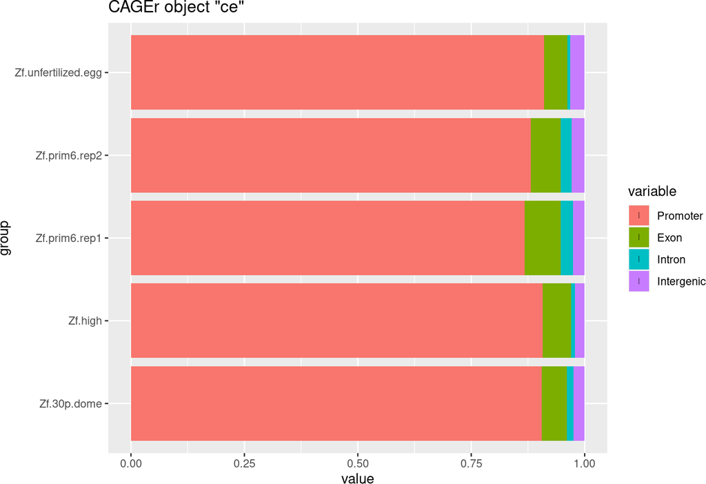

```r
plotAnnot(ce, "counts")
```

### 3.4.2 Correlation between samples

As part of the basic sanity checks, we can explore the data by looking at the correlation between the samples. The `plotCorrelation2()` function will plot pairwise scatter plots of expression scores per TSS or consensus cluster and calculate correlation coefficients between all possible pairs of samples. A threshold can be set, so that only regions with an expression score (raw or normalized) above the threshold (either in one or both samples) are considered when calculating correlation. Three different correlation measures are supported: Pearson’s, Spearman’s and Kendall’s correlation coefficients. Note that while the scatterplots are on a logarithmic scale with pseudocount added to the zero values, the correlation coefficients are calculated on untransformed (but thresholded) data.

Alternatively, the `plotCorrelation()` function does the same and colors the scatterplots according to point density, but is much slower.

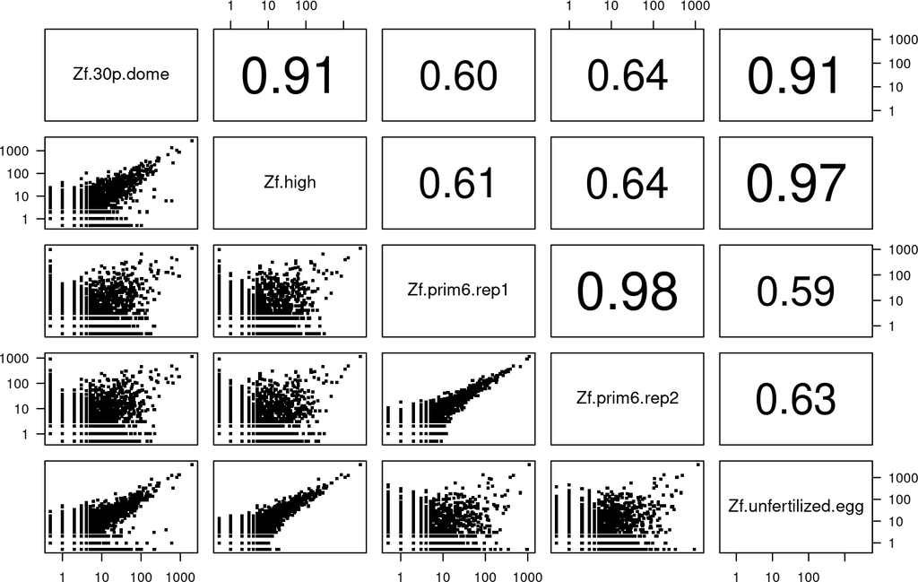

Figure 2: Correlation of raw CAGE tag counts per TSS

```r
corr.m <- plotCorrelation2( ce, samples = "all"
                          , tagCountThreshold = 1, applyThresholdBoth = FALSE
                          , method = "pearson")
```

## 3.5 Merging of replicates

Based on calculated correlation we might want to merge and/or rearrange some of the datasets. To rearrange the samples in the temporal order of the zebrafish development (unfertilized egg -> high -> 30 percent dome -> prim6) and to merge the two replicas for the prim6 developmental stage we use the `mergeSamples()` function:

```r
ce <- mergeSamples(ce, mergeIndex = c(3,2,4,4,1),
                   mergedSampleLabels = c("Zf.unfertilized.egg", "Zf.high", "Zf.30p.dome", "Zf.prim6"))
ce <- annotateCTSS(ce, exampleZv9_annot)
```

The `mergeIndex` argument controls which samples will be merged and how the final dataset will be ordered. Samples labeled by the same number (in our case samples three and four) will be merged together by summing number of CAGE tags per TSS. The final set of samples will be ordered in the ascending order of values provided in `mergeIndex` and will be labeled by the labels provided in the `mergedSampleLabels` argument. Note that `mergeSamples` function resets all slots with results of downstream analyses, so in case there were any results in the *CAGEexp* object prior to merging, they will be removed. Thus, annotation has to be redone.

## 3.6 Normalization

Library sizes (number of total sequenced tags) of individual experiments differ, thus normalization is required to make them comparable. The `librarySizes` function returns the total number of CAGE tags in each sample:

```r
librarySizes(ce)
```

```
## [1] 56140 45910 41814 69000
```

$$y = -1 * \alpha * x + \beta$$

and is fully determined by the slope $\alpha$ and total number of tags T (which together with $\alpha$ determines the value of $\beta$).

To check whether our CAGE datasets follow power-law distribution and in which range of values, we can use the `plotReverseCumulatives` function:

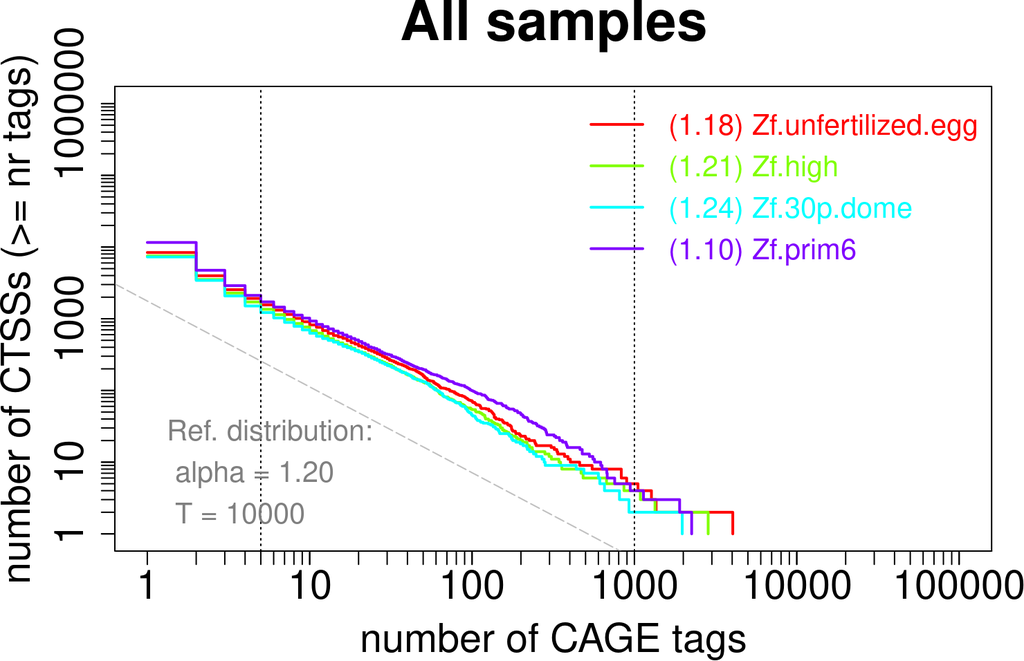

Figure 3: Reverse cumulative distribution of CAGE tags

```r
plotReverseCumulatives(ce, fitInRange = c(5, 1000), onePlot = TRUE)
```

In addition to the reverse cumulative plots (Figure 3), a power-law distribution will be fitted to each reverse cumulative using values in the specified range (denoted with dashed lines in Figure 3) and the value of $\alpha$ will be reported for each sample (shown in the brackets in the Figure 3 legend). The plots can help in choosing the optimal parameters for power-law based normalization. We can see that the reverse cumulative distributions look similar and follow the power-law in the central part of the CAGE tag counts values with a slope between -1.1 and -1.3. Thus, we choose a range from 5 to 1000 tags to fit a power-law, and we normalize all samples to a referent power-law distribution with a total of 50,000 tags and slope of -1.2 ($\alpha = 1.2$).

Note that since this example dataset contains only data from one part of chromosome 17 and the total number of tags is very small, we normalize to a referent distribution with a similarly small number of tags. When analyzing full datasets it is reasonable to set total number of tags for referent distribution to one million to get normalized tags per million values.

To perform normalization we pass these parameters to the `normalizeTagCount` function.

```r
ce <- normalizeTagCount(ce, method = "powerLaw", fitInRange = c(5, 1000), alpha = 1.2, T = 5*10^4)
ce[["tagCountMatrix"]]
```

```
## class: RangedSummarizedExperiment
## dim: 23343 4
## metadata(0):
## assays(2): counts normalizedTpmMatrix
## rownames: NULL
## rowData names(2): genes annotation
## colnames(4): Zf.unfertilized.egg Zf.high Zf.30p.dome Zf.prim6
## colData names(0):
```

The normalization is performed as described in (Balwierz et al. 2009):

- Power-law is fitted to the reverse cumulative distribution in the specified range of CAGE tags values to each sample separately.
- A referent power-law distribution is defined based on the provided `alpha` (slope in the log-log representation) and `T` (total number of tags) parameters. Setting `T` to 1 million results in normalized tags per million (tpm) values.
- Every sample is normalized to the defined referent distribution, *i.e.* given the parameters that approximate its own power-law distribution it is calculated how many tags would each TSS have in the referent power-law distribution.

In addition to the two provided normalization methods, a pass-through option `none` can be set as `method` parameter to keep using raw tag counts in all downstream steps. Note that `normalizeTagCount()` has to be applied to `CAGEr` object before moving to next steps. Thus, in order to keep using raw tag counts run the function with `method="none"`. In that case, all results and parameters in the further steps that would normally refer to normalized CAGE signal (denoted as tpm), will actually be raw tag counts.

## 3.7 CTSS clustering

Transcription start sites are found in the promoter region of a gene and reflect the transcriptional activity of that promoter (Figure 5). TSSs in the close proximity of each other give rise to a functionally equivalent set of transcripts and are likely regulated by the same promoter elements. Thus, TSSs can be spatially clustered into larger transcriptional units, called tag clusters (TCs) that correspond to individual promoters. *CAGEr* supports three methods for spatial clustering of TSSs along the genome, two *ab initio* methods driven by the data itself, as well as assigning TSSs to predefined genomic regions:

- Simple distance-based clustering in which two neighbouring TSSs are joined together if they are closer than some specified distance (greedy algorithm);
- Parametric clustering of data attached to sequences based on the density of the signal (Frith et al. 2007), http://www.cbrc.jp/paraclu/;
- Counting TSSs and their signal in a set of user supplied genomic regions (*e.g.* annotation derived promoter regions or other regions of interest).

These functionalities are provided in the function `clusterCTSS()`, which accepts additional arguments for controlling which CTSSs will be included in the clustering as well as for refining the final set of tag clusters.

We will perform a simple distance-based clustering using 20 bp as a maximal allowed distance between two neighbouring TSSs. Prior to clustering we will filter out low-fidelity TSSs - the ones supported by less than 1 normalized tag counts in all of the samples.

```r
ce <- clusterCTSS( ce
                 , threshold = 1
                 , thresholdIsTpm = TRUE
                 , nrPassThreshold = 1
                 , method = "distclu"
                 , maxDist = 20
                 , removeSingletons = TRUE
                 , keepSingletonsAbove = 5)
```

Our final set of tag clusters will not include singletons (clusters with only one TSS), unless the normalized signal is above 5, it is a reasonably supported TSS. The `clusterCTSS` function creates a set of clusters for each sample separately; for each cluster it returns the genomic coordinates, counts the number of TSSs within the cluster, determines the position of the most frequently used (dominant) TSS, calculates the total CAGE signal within the cluster and CAGE signal supporting the dominant TSS only. We can extract tag clusters for a desired sample from `CAGEexp` object by calling the `tagClustersGR` function:

```r
tagClustersGR(ce, sample = "Zf.unfertilized.egg")
```

```
## TagClusters object with 517 ranges and 4 metadata columns:
##       seqnames            ranges strand |            score   nr_ctss
##          <Rle>         <IRanges>  <Rle> |            <Rle> <integer>
##     1    chr17 26453632-26453708      + | 26.9709371501973        12
##     2    chr17 26564508-26564610      + | 128.637202208017        24
##     3    chr17 26595637-26595793      + | 216.999442534332        35
##     4    chr17 26596033-26596091      + | 10.4200035230486         9
##     5    chr17 26596118-26596127      + | 12.1994648486481         4
##   ...      ...               ...    ... .              ...       ...
##   513    chr17 45700182-45700187      - | 9.61820033171689         3
##   514    chr17 45901329-45901330      - | 1.96212698267798         2
##   515    chr17 45901698-45901710      - | 27.6544648890639         4
##   516    chr17 45901732-45901784      - |  119.96944736195        15
##   517    chr17 45901814-45901816      - | 3.24804276430515         2
##       dominant_ctss tpm.dominant_ctss
##           <integer>             <Rle>
##     1      26453667  8.25013739501972
##     2      26564585  29.2832717171977
##     3      26595750  100.970036599366
##     4      26596070  3.21686412708414
##     5      26596118  5.74180188433636
##   ...           ...               ...
##   513      45700182  6.37015756741174
##   514      45901329  1.30374775871268
##   515      45901698  23.7480429007934
##   516      45901749  83.4545595936441
##   517      45901816  1.94429500559247
##   -------
##   seqinfo: 26 sequences (1 circular) from danRer7 genome
```

## 3.8 Promoter width

Genome-wide mapping of TSSs using CAGE has initially revealed two major classes of promoters in mammals (Carninci et al. 2006), with respect to the number and distribution of TSSs within the promoter. They have been further correlated with differences in the underlying sequence and the functional classes of the genes they regulate, as well as the organization of the chromatin around them.

- “broad” promoters with multiple TSSs characterized by a high GC content and overlap with a CpG island, which are associated with widely expressed or developmentally regulated genes;
- “sharp” promoters with one dominant TSS often associated with a TATA-box at a fixed upstream distance, which often regulate tissue-specific transcription.

Thus, the width of the promoter is an important characteristic that distinguishes different functional classes of promoters. *CAGEr* analyzes promoter width across all samples present in the `CAGEexp` object. It defines promoter width by taking into account both the positions and the CAGE signal at TSSs along the tag cluster, thus making it more robust with respect to total expression and local level of noise at the promoter. Width of every tag cluster is calculated as following:

1. Cumulative distribution of CAGE signal along the cluster is calculated.
2. A “lower” (`qLow`) and an “upper” (`qUp`) quantile are selected by the user.
3. From the 5′ end the position, the position of a quantile $q$ is detemined as the first base in which of the cumulative expression is higher or equal to $q\%$ of the total CAGE signal of that cluster.
4. Promoter *interquantile width* is defined as the distance (in base pairs) between the two quantile positions.

The procedure is schematically shown in Figure 4.

[figure not shown]

Figure 4: Cumulative distribution of CAGE signal and definition of interquantile width

Required computations are done using `cumulativeCTSSdistribution` and `quantilePositions` functions, which calculate cumulative distribution for every tag cluster in each of the samples and determine the positions of selected quantiles, respectively:

```r
ce <- cumulativeCTSSdistribution(ce, clusters = "tagClusters", useMulticore = T)
ce <- quantilePositions(ce, clusters = "tagClusters", qLow = 0.1, qUp = 0.9)
```

Tag clusters and their interquantile width can be retrieved by calling `tagClusters` function:

```r
tagClustersGR( ce, "Zf.unfertilized.egg"
             , returnInterquantileWidth = TRUE,  qLow = 0.1, qUp = 0.9)
```

```
## TagClusters object with 517 ranges and 7 metadata columns:
##       seqnames            ranges strand |            score   nr_ctss
##          <Rle>         <IRanges>  <Rle> |            <Rle> <integer>
##     1    chr17 26453632-26453708      + | 26.9709371501973        12
##     2    chr17 26564508-26564610      + | 128.637202208017        24
##     3    chr17 26595637-26595793      + | 216.999442534332        35
##     4    chr17 26596033-26596091      + | 10.4200035230486         9
##     5    chr17 26596118-26596127      + | 12.1994648486481         4
##   ...      ...               ...    ... .              ...       ...
##   513    chr17 45700182-45700187      - | 9.61820033171689         3
##   514    chr17 45901329-45901330      - | 1.96212698267798         2
##   515    chr17 45901698-45901710      - | 27.6544648890639         4
##   516    chr17 45901732-45901784      - |  119.96944736195        15
##   517    chr17 45901814-45901816      - | 3.24804276430515         2
##       dominant_ctss tpm.dominant_ctss q_0.1 q_0.9 interquantile_width
##           <integer>             <Rle> <Rle> <Rle>               <Rle>
##     1      26453667  8.25013739501972    36    72                  37
##     2      26564585  29.2832717171977    17    81                  65
##     3      26595750  100.970036599366    37   114                  78
##     4      26596070  3.21686412708414     1    50                  50
##     5      26596118  5.74180188433636     1    10                  10
##   ...           ...               ...   ...   ...                 ...
##   513      45700182  6.37015756741174     1     6                   6
##   514      45901329  1.30374775871268     1     2                   2
##   515      45901698  23.7480429007934     1     2                   2
##   516      45901749  83.4545595936441     2    21                  20
##   517      45901816  1.94429500559247     1     3                   3
##   -------
##   seqinfo: 26 sequences (1 circular) from danRer7 genome
```

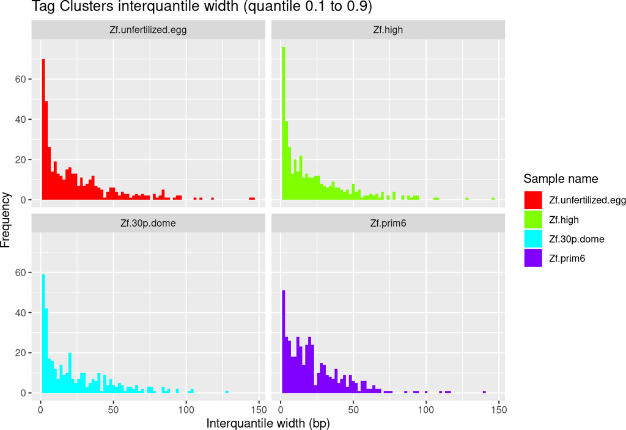

```r
plotInterquantileWidth(ce, clusters = "tagClusters", tpmThreshold = 3, qLow = 0.1, qUp = 0.9)
```

Significant difference in the promoter width might indicate global differences in the modes of gene regulation between the two samples. The histograms can also help in choosing an appropriate width threshold for separating sharp and broad promoters.

## 3.9 Creating consensus promoters across samples

Tag clusters are created for each sample individually and they are often sample-specific, thus can be present in one sample but absent in another. In addition, in many cases tag clusters do not coincide perfectly within the same promoter region, or there might be two clusters in one sample and only one larger in the other. To be able to compare genome-wide transcriptional activity across samples and to perform expression profiling, a single set of consensus clusters needs to be created. This is done using the `aggregateTagClusters` function, which aggregates tag clusters from all samples into a single set of non-overlapping consensus clusters:

```r
ce <- aggregateTagClusters(ce, tpmThreshold = 5, qLow = 0.1, qUp = 0.9, maxDist = 100)
ce$outOfClusters / ce$librarySizes *100
```

```
## Zf.unfertilized.egg             Zf.high         Zf.30p.dome            Zf.prim6
##                34.0                33.7                32.9                35.1
```

Tag clusters can be aggregated using their full span (from start to end) or using positions of previously calculated quantiles as their boundaries. Only tag clusters above given tag count threshold will be considered and two clusters will be aggregated together if their boundaries (i.e. either starts and ends or positions of quantiles) are `<= maxDist` apart. Final set of consensus clusters can be retrieved by:

```r
consensusClustersGR(ce)
```

```
## ConsensusClusters object with 256 ranges and 3 metadata columns:
##                             seqnames            ranges strand |     score
##                                <Rle>         <IRanges>  <Rle> | <numeric>
##   chr17:26379388-26379678:-    chr17 26379388-26379678      - |  179.8039
##   chr17:26446559-26446644:-    chr17 26446559-26446644      - |   48.1655
##   chr17:26452451-26452553:-    chr17 26452451-26452553      - |  184.2043
##   chr17:26453648-26453720:+    chr17 26453648-26453720      + |  129.7335
##   chr17:26555294-26555351:-    chr17 26555294-26555351      - |   19.2388
##                         ...      ...               ...    ... .       ...
##   chr17:45700093-45700188:-    chr17 45700093-45700188      - |   9.21467
##   chr17:45806843-45806887:+    chr17 45806843-45806887      + | 108.34521
##   chr17:45901696-45901753:-    chr17 45901696-45901753      - | 789.81397
##   chr17:45905581-45905662:+    chr17 45905581-45905662      + | 321.12535
##   chr17:45975253-45975294:+    chr17 45975253-45975294      + |  35.81631
##                             consensus.cluster       tpm
##                                     <integer> <numeric>
##   chr17:26379388-26379678:-               196  287.2479
##   chr17:26446559-26446644:-               197   85.7757
##   chr17:26452451-26452553:-               198  269.6895
##   chr17:26453648-26453720:+                 1  185.9678
##   chr17:26555294-26555351:-               199   47.6677
##                         ...               ...       ...
##   chr17:45700093-45700188:-               371   23.2038
##   chr17:45806843-45806887:+               190  173.6142
##   chr17:45901696-45901753:-               375  875.8315
##   chr17:45905581-45905662:+               192  392.2361
##   chr17:45975253-45975294:+               193   55.6241
##   -------
##   seqinfo: 26 sequences from an unspecified genome; no seqlengths
```

which will return genomic coordinates and sum of CAGE signal across all samples for each consensus cluster (the `tpm` column).

Analogously to tag clusters, analysis of promoter width can be performed for consensus clusters as well, using the same `cumulativeCTSSdistribution`, `quantilePositions` and `plotInterquantileWidth` functions as described above, but by setting the `clusters` parameter to `"consensusClusters"`. Like the CTSS, the consensus clusters can also be annotated:

```r
ce <- annotateConsensusClusters(ce, exampleZv9_annot)
ce <- cumulativeCTSSdistribution(ce, clusters = "consensusClusters", useMulticore = TRUE)
ce <- quantilePositions(ce, clusters = "consensusClusters", qLow = 0.1, qUp = 0.9, useMulticore = TRUE)
```

Although consensus clusters are created to represent consensus across all samples, they obviously have different CAGE signal and can have different width or position of the dominant TSS in the different samples. Sample-specific information on consensus clusters can be retrieved with the function, by specifying desired sample name (analogous to retrieving tag clusters):

```r
consensusClustersGR( ce, sample = "Zf.unfertilized.egg"
                       , returnInterquantileWidth = TRUE,  qLow = 0.1, qUp = 0.9)
```

```
## ConsensusClusters object with 256 ranges and 8 metadata columns:
##                             seqnames            ranges strand |     score
##                                <Rle>         <IRanges>  <Rle> | <numeric>
##   chr17:26379388-26379678:-    chr17 26379388-26379678      - |  49.51468
##   chr17:26446559-26446644:-    chr17 26446559-26446644      - |  10.91385
##   chr17:26452451-26452553:-    chr17 26452451-26452553      - |  61.86586
##   chr17:26453648-26453720:+    chr17 26453648-26453720      + |  19.13544
##   chr17:26555294-26555351:-    chr17 26555294-26555351      - |   6.37016
##                         ...      ...               ...    ... .       ...
##   chr17:45700093-45700188:-    chr17 45700093-45700188      - |   6.37016
##   chr17:45806843-45806887:+    chr17 45806843-45806887      + |  23.04049
##   chr17:45901696-45901753:-    chr17 45901696-45901753      - | 132.65464
##   chr17:45905581-45905662:+    chr17 45905581-45905662      + | 106.79616
##   chr17:45975253-45975294:+    chr17 45975253-45975294      + |   0.00000
##                             consensus.cluster       tpm annotation
##                                     <integer> <numeric>      <Rle>
##   chr17:26379388-26379678:-               196  49.51468   promoter
##   chr17:26446559-26446644:-               197  10.91385   promoter
##   chr17:26452451-26452553:-               198  61.86586   promoter
##   chr17:26453648-26453720:+                 1  19.13544   promoter
##   chr17:26555294-26555351:-               199   6.37016       exon
##                         ...               ...       ...        ...
##   chr17:45700093-45700188:-               371   6.37016       exon
##   chr17:45806843-45806887:+               190  23.04049   promoter
##   chr17:45901696-45901753:-               375 132.65464   promoter
##   chr17:45905581-45905662:+               192 106.79616   promoter
##   chr17:45975253-45975294:+               193   0.00000    unknown
##                                       genes q_0.1 q_0.9 interquantile_width
##                                       <Rle> <Rle> <Rle>               <Rle>
##   chr17:26379388-26379678:- CCSER2 (1 of 2)    20    56                  37
##   chr17:26446559-26446644:-        fam149b1    31    65                  35
##   chr17:26452451-26452553:-           mrp63    43    77                  35
##   chr17:26453648-26453720:+           ttc7b    37   271                 235
##   chr17:26555294-26555351:-          calm1a     3   109                 107
##                         ...             ...   ...   ...                 ...
##   chr17:45700093-45700188:-           susd4     1     1                   1
##   chr17:45806843-45806887:+          vcpkmt    26    69                  44
##   chr17:45901696-45901753:-           arf6b    25    31                   7
##   chr17:45905581-45905662:+            aspg     3    92                  90
##   chr17:45975253-45975294:+                     3    54                  52
##   -------
##   seqinfo: 26 sequences from an unspecified genome; no seqlengths
```

## 3.10 Track export for genome browsers

CAGE data can be visualized in the genomic context by converting raw or normalized CAGE tag counts to a track object and exporting it to a file format such as *BED*, *bedGraph* or *BigWig* for uploading (or linking) to a genome browser`. The (exportToTrack) function can take a variety of inputs representing *CTSS*, *Tag Clusters* or *Consensus Clusters*, with raw or normalised expression scores. When asked to export multiple samples it will return a list of tracks.

Note that the [ZENBU genome browser](http://fantom.gsc.riken.jp/zenbu) can also display natively data from BAMor BED files as coverage tracks.

```r
trk <- exportToTrack(CTSSnormalizedTpmGR(ce, "Zf.30p.dome"))
ce |> CTSSnormalizedTpmGR("all") |> exportToTrack(ce, oneTrack = FALSE)
```

```
## GRangesList object of length 4:
## [[1]]
## UCSC track 'Zf.unfertilized.egg (TC)'
## UCSCData object with 8395 ranges and 6 metadata columns:
##          seqnames    ranges strand |           genes annotation filteredCTSSidx
##             <Rle> <IRanges>  <Rle> |           <Rle>      <Rle>           <Rle>
##      [1]    chr17  26050540      + |          grid1a   promoter           FALSE
##      [2]    chr17  26391265      + | si:ch73-34j14.2       exon           FALSE
##      [3]    chr17  26446219      + |                    unknown           FALSE
##      [4]    chr17  26453605      + |                   promoter            TRUE
##      [5]    chr17  26453632      + |                   promoter            TRUE
##      ...      ...       ...    ... .             ...        ...             ...
##   [8391]    chr17  45901781      - |           arf6b   promoter           FALSE
##   [8392]    chr17  45901784      - |           arf6b   promoter            TRUE
##   [8393]    chr17  45901800      - |           arf6b   promoter           FALSE
##   [8394]    chr17  45901814      - |           arf6b   promoter            TRUE
##   [8395]    chr17  45901816      - |           arf6b   promoter            TRUE
##          cluster     score     itemRgb
##            <Rle> <numeric> <character>
##      [1]          0.658379      grey50
##      [2]          0.658379      grey50
##      [3]          0.658379      grey50
##      [4]          1.303748       black
##      [5]          1.303748       black
##      ...     ...       ...         ...
##   [8391]          0.658379      grey50
##   [8392]          0.658379       black
##   [8393]          0.658379      grey50
##   [8394]          1.303748       black
##   [8395]          1.944295       black
##   -------
##   seqinfo: 26 sequences (1 circular) from danRer7 genome
##
## ...
## <3 more elements>
```

Some track file format, for instance *bigWig* or *bedGraph* require the `+` and `-` strands to be separated, because they do not allow overlapping ranges. This can be done with the (split) function like in the following example.

The `drop = TRUE` option is needed to remove the `*` level.

```r
split(trk, strand(trk), drop = TRUE)
```

```
## GRangesList object of length 2:
## $`+`
## UCSC track 'Zf.30p.dome (TC)'
## UCSCData object with 3778 ranges and 6 metadata columns:
##          seqnames    ranges strand | genes annotation filteredCTSSidx
##             <Rle> <IRanges>  <Rle> | <Rle>      <Rle>           <Rle>
##      [1]    chr17  26222417      + |          unknown           FALSE
##      [2]    chr17  26323229      + |          unknown           FALSE
##      [3]    chr17  26453603      + |         promoter            TRUE
##      [4]    chr17  26453615      + |         promoter           FALSE
##      [5]    chr17  26453632      + |         promoter            TRUE
##      ...      ...       ...    ... .   ...        ...             ...
##   [3774]    chr17  45975288      + |          unknown            TRUE
##   [3775]    chr17  45975289      + |          unknown            TRUE
##   [3776]    chr17  45975290      + |          unknown            TRUE
##   [3777]    chr17  45975292      + |          unknown            TRUE
##   [3778]    chr17  45975293      + |          unknown            TRUE
##                         cluster     score     itemRgb
##                           <Rle> <numeric> <character>
##      [1]                         0.680723      grey50
##      [2]                         0.680723      grey50
##      [3]                         1.394796       black
##      [4]                         0.680723      grey50
##      [5]                         2.122024       black
##      ...                    ...       ...         ...
##   [3774] chr17:45975253-45975..  10.44998       black
##   [3775] chr17:45975253-45975..   1.39480       black
##   [3776] chr17:45975253-45975..   4.34801       black
##   [3777] chr17:45975253-45975..   1.39480       black
##   [3778] chr17:45975253-45975..   2.85793       black
##   -------
##   seqinfo: 26 sequences (1 circular) from danRer7 genome
##
## $`-`
## UCSC track 'Zf.30p.dome (TC)'
## UCSCData object with 3499 ranges and 6 metadata columns:
##          seqnames    ranges strand | genes annotation filteredCTSSidx cluster
##             <Rle> <IRanges>  <Rle> | <Rle>      <Rle>           <Rle>   <Rle>
##      [1]    chr17  26068225      - |          unknown           FALSE
##      [2]    chr17  26068227      - |          unknown           FALSE
```

[output cut: 9 more lines]

```
##              score     itemRgb
##          <numeric> <character>
##      [1]  0.680723      grey50
##      [2]  0.680723      grey50
##      [3]  0.680723      grey50
##      [4]  1.394796       black
##      [5]  0.680723      grey50
##      ...       ...         ...
##   [3495]  0.680723      grey50
##   [3496]  0.680723       black
##   [3497]  0.680723       black
##   [3498]  0.680723      grey50
##   [3499]  0.680723      grey50
##   -------
##   seqinfo: 26 sequences (1 circular) from danRer7 genome
```

For *bigWig* export, the (rtracklayer::export.bw) needs to be run on each element of the list returned by the (split) command.

For *bedGraph* export, the (rtracklayer::export.bedGraph) command can take the list as input and will produce a single file containing the two tracks. (Figure 5) shows an example of *bedGraph* visualisation.

For *BED* export, the (rtracklayer::export.bed) can operate directly on the track object.

Other export format probably operate in a way similar to one of the cases above.

[figure not shown]

Figure 5: CAGE data bedGraph track visualized in the UCSC Genome Browser

Interquantile width can also be visualized in a gene-like representation in the genome browsers by passing quantile information during data conversion to the *UCSCData* format and then exporting it into a *BED* file:

```r
iqtrack <- exportToTrack(ce, what = "tagClusters", qLow = 0.1, qUp = 0.9, oneTrack = FALSE)
iqtrack
```

```
## GRangesList object of length 4:
## $Zf.unfertilized.egg
## UCSC track 'TC'
## UCSCData object with 517 ranges and 6 metadata columns:
##         seqnames            ranges strand |     score q_0.1 q_0.9     thick
##            <Rle>         <IRanges>  <Rle> | <integer> <Rle> <Rle> <IRanges>
##     [1]    chr17 26453632-26453708      + |         0    36    72  26453667
##     [2]    chr17 26564508-26564610      + |         0    17    81  26564585
##     [3]    chr17 26595637-26595793      + |         0    37   114  26595750
##     [4]    chr17 26596033-26596091      + |         0     1    50  26596070
##     [5]    chr17 26596118-26596127      + |         0     1    10  26596118
##     ...      ...               ...    ... .       ...   ...   ...       ...
##   [513]    chr17 45700182-45700187      - |         0     1     6  45700182
##   [514]    chr17 45901329-45901330      - |         0     1     2  45901329
##   [515]    chr17 45901698-45901710      - |         0     1     2  45901698
##   [516]    chr17 45901732-45901784      - |         0     2    21  45901749
##   [517]    chr17 45901814-45901816      - |         0     1     3  45901816
##              name        blocks
##         <logical> <IRangesList>
##     [1]      <NA>    1,36-72,77
##     [2]      <NA>   1,17-81,103
##     [3]      <NA>  1,37-114,157
##     [4]      <NA>       1-50,59
##     [5]      <NA>          1-10
##     ...       ...           ...
##   [513]      <NA>           1-6
##   [514]      <NA>           1-2
##   [515]      <NA>        1-2,13
##   [516]      <NA>     1,2-21,53
##   [517]      <NA>           1-3
##   -------
##   seqinfo: 26 sequences (1 circular) from danRer7 genome
##
## ...
## <3 more elements>
```

```r
#rtracklayer::export.bed(iqtrack, "outputFileName.bed")
```

In this gene-like representation (Figure 6), the oriented line shows the full span of the cluster, filled block marks the interquantile width and a single base-pair thick block denotes the position of the dominant TSS.

[figure not shown]

Figure 6: Tag clusters visualization in the genome browser

## 3.11 Expression profiling

The CAGE signal is a quantitative measure of promoter activity. In *CAGEr*, normalised expression scores of individual CTSSs or consensus clusters can be clustered in *expression classes*. Two unsupervised clustering algorithms are supported: kmeans and self-organizing maps (SOM). Both require to specify a number of clusters in advance. Results are stored in the `exprClass` *metadata column* of the CTSS or consensus clusters genomic ranges, and the `expressionClass` accessor function is provided for convenience.

In the example below, we perform expression clustering at the level of entire promoters using SOM algorithm with 4 × 2 dimensions and applying it only to consensus clusters with a normalized CAGE signal of at least 10 TPM in at least one sample.

```r
ce <- getExpressionProfiles(ce, what = "consensusClusters", tpmThreshold = 10,
  nrPassThreshold = 1, method = "som", xDim = 4, yDim = 2)
consensusClustersGR(ce)$exprClass |> table(useNA = "always")
```

```
##
##  0_0  0_1  1_0  1_1  2_0  2_1  3_0  3_1 <NA>
##   41   39   22   26   18    6    9   37   58
```

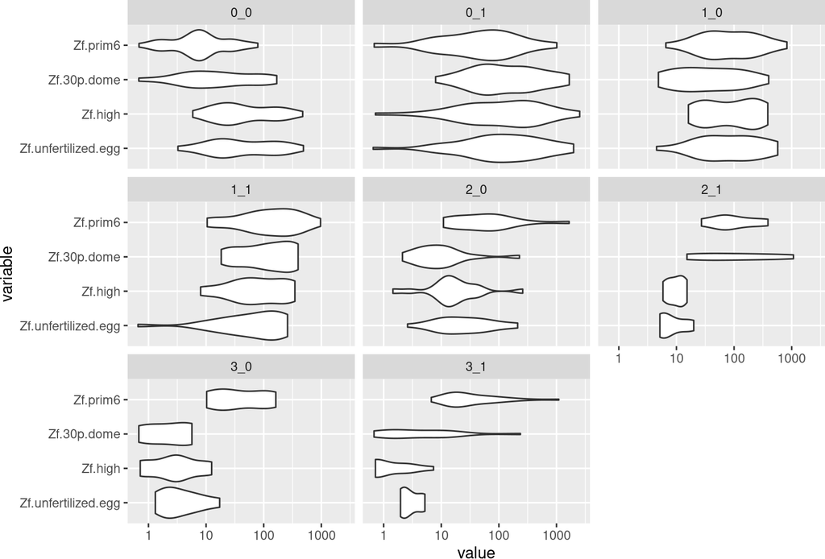

[figure not shown]

```r
plotExpressionProfiles(ce, what = "consensusClusters")
```

```r
consensusClustersGR(ce) |> subset(consensusClustersGR(ce)$exprClass ==  "0_1")
```

```
## ConsensusClusters object with 39 ranges and 6 metadata columns:
##                             seqnames            ranges strand |     score
##                                <Rle>         <IRanges>  <Rle> | <numeric>
##   chr17:26379388-26379678:-    chr17 26379388-26379678      - |   179.804
##   chr17:26562674-26562694:-    chr17 26562674-26562694      - |  1310.436
##   chr17:26645158-26645515:+    chr17 26645158-26645515      + |  2293.601
##   chr17:26651965-26652051:+    chr17 26651965-26652051      + |    51.707
##   chr17:28161575-28161758:+    chr17 28161575-28161758      + |  1199.885
##                         ...      ...               ...    ... .       ...
##   chr17:44487318-44487410:-    chr17 44487318-44487410      - | 1215.7853
##   chr17:45175978-45175991:-    chr17 45175978-45175991      - |   31.9905
##   chr17:45545923-45545997:-    chr17 45545923-45545997      - |  854.2839
##   chr17:45572279-45572313:+    chr17 45572279-45572313      + |   35.3124
##   chr17:45905581-45905662:+    chr17 45905581-45905662      + |  321.1253
##                             consensus.cluster       tpm annotation
##                                     <integer> <numeric>      <Rle>
##   chr17:26379388-26379678:-               196  287.2479   promoter
##   chr17:26562674-26562694:-               200 1512.1280   promoter
##   chr17:26645158-26645515:+                 5 2844.4560   promoter
##   chr17:26651965-26652051:+                 6   71.0783       exon
##   chr17:28161575-28161758:+                24 1303.5286   promoter
##                         ...               ...       ...        ...
##   chr17:44487318-44487410:-               356 1705.0576   promoter
##   chr17:45175978-45175991:-               357   35.1668   promoter
##   chr17:45545923-45545997:-               368 1017.2242   promoter
##   chr17:45572279-45572313:+               186   39.4686   promoter
##   chr17:45905581-45905662:+               192  392.2361   promoter
##                                       genes exprClass
##                                       <Rle>     <Rle>
##   chr17:26379388-26379678:- CCSER2 (1 of 2)       0_1
##   chr17:26562674-26562694:-          calm1a       0_1
##   chr17:26645158-26645515:+          pgrmc2       0_1
##   chr17:26651965-26652051:+          pgrmc2       0_1
##   chr17:28161575-28161758:+         TMEM30B       0_1
##                         ...             ...       ...
##   chr17:44487318-44487410:-           exoc5       0_1
##   chr17:45175978-45175991:-         fam161b       0_1
##   chr17:45545923-45545997:-         znf106a       0_1
##   chr17:45572279-45572313:+          tagapa       0_1
##   chr17:45905581-45905662:+            aspg       0_1
##   -------
##   seqinfo: 26 sequences from an unspecified genome; no seqlengths
```

Consensus clusters and information on their expression profile can be exported to a BED file, which allows visualization of the promoters in the genome browser colored in the color of the expression cluster they belong to (Figure 7:

```r
# Not supported yet for CAGEexp objects, sorry.
# exportToBed(ce, what = "consensusClusters",
#       colorByExpressionProfile = TRUE)
```

[figure not shown]

Figure 7: Consensus clusters colored by expression profile in the genome browser

Expression profiling of individual TSSs is done using the same procedure as described above for consensus clusters, only by setting `wha = "CTSS"` in all of the functions.

## 3.12 Differential expression analysis

The raw expression table for the consensus clusters can be exported to the *DESeq2* package for differential expression analysis. For this, the column data needs to contain factors that can group the samples. They can have any name.

```r
ce$group <- factor(c("a", "a", "b", "b"))
dds <- consensusClustersDESeq2(ce, ~group)
```

## 3.13 Shifting promoters

```r
ce <- cumulativeCTSSdistribution(ce, clusters = "consensusClusters")
```

Next, we calculate a shifting score and P-value of Kolmogorov-Smirnov test for all promoters comparing two specified samples:

```r
# Not supported yet for CAGEexp objects, sorry.
# scoreShift(ce, groupX = "Zf.unfertilized.egg", groupY = "zf_prim6",
#       testKS = TRUE, useTpmKS = FALSE)
```

This function will calculate shifting score as illustrated in Figure 8. Values of shifting score are in range between `-Inf` and `1`. Positive values can be interpreted as the proportion of transcription initiation in the sample with lower expression that is happening “outside” (either upstream or downstream) of the region used for transcription initiation in the other sample. In contrast, negative values indicate no physical separation, *i.e.* the region used for transcription initiation in the sample with lower expression is completely contained within the region used for transcription initiation in the other sample. Thus, shifting score detects only the degree of upstream or downstream shifting, but does not detect more general changes in TSS rearrangement in the region, *e.g.* narrowing or broadening of the region used for transcription.

To assess any general change in the TSS usage within the promoter region, a two-sample Kolmogorov-Smirnov (K-S) test on cumulative sums of CAGE signal along the consensus cluster is performed. Cumulative sums in both samples are scaled to range between 0 and 1 and are considered to be empirical cumulative distribution functions (ECDF) reflecting sampling of TSS positions during transcription initiation. K-S test is performed to assess whether the two underlying probability distributions differ. To obtain a P-value *i.e.* the level at which the null-hypothesis can be rejected), sample sizes that generated the ECDFs are required, in addition to actual K-S statistics calculated from ECDFs. These are derived either from raw tag counts, *i.e.* exact number of times each TSS in the cluster was sampled during sequencing (when `useTpmKS = FALSE`), or from normalized tpm values (when `useTpmKS = TRUE`). P-values obtained from K-S tests are further corrected for multiple testing using Benjamini and Hochenberg (BH) method and for each P-value a corresponding false-discovery rate (FDR) is also reported.

[figure not shown]

Figure 8: Calculation of shifting score

We can select a subset of promoters with shifting score and/or FDR above specified threshold:

```r
# Not supported yet for CAGEexp objects, sorry.
# shifting.promoters <- getShiftingPromoters(ce,
#       tpmThreshold = 5, scoreThreshold = 0.6,
#       fdrThreshold = 0.01)
# head(shifting.promoters)
```

The `getShiftingPromoters` function returns genomic coordinates, shifting score and P-value (FDR) of the promoters, as well as the value of CAGE signal and position of the dominant TSS in the two compared (groups of) samples. Figure 9 shows the difference in the CAGE signal between the two compared samples for one of the selected high-scoring shifting promoters.

[figure not shown]

Figure 9: Example of shifting promoter

# 4 Appendix

## 4.1 Creating a `CAGEexp` object by coercing a data frame

A *CAGEexp* object can also be created directly by coercing a data frame containing single base-pair TSS information. To be able to do the coercion into a *CAGEexp*, the data frame must conform with the following:

- The data frame must have at least 4 columns;
- the first three columns must be named `chr`, `pos` and `strand`, and contain chromosome name, 1-based genomic coordinate of the TSS (positive integer) and TSS strand information (`+` or `-`), respectively;
- these first three columns must be of the class `character`, `integer` and `character`, respectively;
- all additional columns must be of the class `integer` and should contain raw CAGE tag counts (non-negative integer) supporting each TSS in different samples (columns). At least one such column with tag counts must be present;
- the names of the columns containing tag counts must begin with a letter, and these column names are used as sample labels in the resulting *CAGEexp* object.

An example of such data frame is shown below:

```r
TSS.df <- read.table(system.file( "extdata/Zf.unfertilized.egg.chr17.ctss"
                                , package = "CAGEr"))
# make sure the column names are as required
colnames(TSS.df) <- c("chr", "pos", "strand", "Zf.unfertilized.egg")
# make sure the column classes are as required
TSS.df$chr <- as.character(TSS.df$chr)
TSS.df$pos <- as.integer(TSS.df$pos)
TSS.df$strand <- as.character(TSS.df$strand)
TSS.df$Zf.unfertilized.egg <- as.integer(TSS.df$Zf.unfertilized.egg)
head(TSS.df)
```

```
##     chr      pos strand Zf.unfertilized.egg
## 1 chr17 26050540      +                   1
## 2 chr17 26074127      -                   2
## 3 chr17 26074129      -                   3
## 4 chr17 26222545      -                   1
## 5 chr17 26322780      -                   1
## 6 chr17 26322832      -                   2
```

This data.frame can now be coerced to a *CAGEexp* object, which will fill the corresponding slots of the object with provided TSS information:

```r
ce.coerced <- as(TSS.df, "CAGEexp")
ce.coerced
```

```
## A CAGEexp object of 1 listed
##  experiment with a user-defined name and respective class.
##  Containing an ExperimentList class object of length 1:
##  [1] tagCountMatrix: RangedSummarizedExperiment with 8395 rows and 1 columns
## Functionality:
##  experiments() - obtain the ExperimentList instance
##  colData() - the primary/phenotype DataFrame
##  sampleMap() - the sample coordination DataFrame
##  `$`, `[`, `[[` - extract colData columns, subset, or experiment
##  *Format() - convert into a long or wide DataFrame
##  assays() - convert ExperimentList to a SimpleList of matrices
##  exportClass() - save data to flat files
```

## 4.2 Summary of the CAGEr accessor functions

Originally there was one accessor per slot in *CAGEset* objects (the original *CAGEr* format), but now that I added the *CAGEexp* class, that uses different underlying formats, the number of accessors increased because a) I provide the old ones for backwards compatibility and b) there multiple possible output formats.

Before releasing this CAGEr update in Bioconductor, I would like to be sure that the number of accessors and the name scheme are good enough.

Please let me know your opinion about the names and scope of the accessors below:

### 4.2.1 CTSS data

| Name | Output |
| --- | --- |
| CTSScoordinatesGR | Coordinate table in GRanges format. |
| CTSStagCountDA | Raw CTSS counts in DelayedArray format wrapping a integer Rle DataFrame. |
| CTSStagCountDF | Raw CTSS counts in integer Rle DataFrame format. |
| CTSStagCountGR | Raw CTSS counts in GRanges format (single samples). |
| CTSStagCountSE | RangedSummarizedExperiment containing an assay for the Raw CTSS counts. |
| CTSSnormalizedTpmDF | Normalised CTSS values in Rle DataFrame format. |
| CTSSnormalizedTpmGR | Normalised CTSS values in GRanges format (single samples). |

### 4.2.2 Cluster data

| Name | Output |
| --- | --- |
| consensusClustersDESeq2 | Consensus cluster coordinates and expression matrix in DESeq2 format. |
| consensusClustersGR | Consensus cluster coordinates in GRanges format. |
| consensusClustersSE | Consensus cluster coordinates and expression matrix in RangedSummarizedExperiment format. |
| consensusClustersTpm | Consensus cluster coordinates and raw expression matrix. |
| tagClustersGR | Per-sample GRangesList of tag cluster coordinates. |

### 4.2.3 Gene data

| Name | Output |
| --- | --- |
| GeneExpDESeq2 | Gene expression data in DESeq2 format. |
| GeneExpSE | Gene expression data in SummarizedExperiment format. |

## 4.3 Summary of the *CAGEexp* experiment slots and assays

A *CAGEexp* object can contain the following experiments.

Please let me know your opinion about the names

| Name | Assays | Comment |
| --- | --- | --- |
| tagCountMatrix | counts, normalizedTpmMatrix | RangedSummarizedExperiment |
| seqNameTotals | counts, norm | SummarizedExperiment |
| consensusClusters | counts, normalized, q_x, q_y | RangedSummarizedExperiment |
| geneExpMatrix | counts | SummarizedExperiment |

### 4.3.1 CAGEexp assays

| Name | Experiment | Comment |
| --- | --- | --- |
| counts | tagCountMatrix | Integer Rle DataFrame of CTSS raw counts. |
| counts | seqNameTotals | Numeric matrix of total counts per chromosome. |
| counts | consensusClusters | Integer matrix of consensus cluster expression counts. |
| counts | geneExpMatrix | Integer matrix of gene expression counts. |
| normalizedTpmMatrix | tagCountMatrix | Numeric matrix of normalised CTSS expression scores. |
| norm | seqNameTotals | Numeric matrix of percent total counts per chromosome. |
| normalized | consensusClusters | Numeric matrix of normalised CC expression scores. |
| q_x, q_y, q_z, … | consensusClusters | Interger Rle DataFrame of relative quantile positions |

## 4.4 Summary of the CAGEr classes

The CTSS, CTSS.chr, TagCluster and ConsensusClsuters are mostly used internally or type safety and preventing me (Charles) from mixing up inputs. They are visible from the outside. Should they be used more extensively ? Can they be replaced by more “core” Bioconductor classes ?

| Name | Comment |
| --- | --- |
| CAGEset | The original CAGEr class, based on data frames and matrices. |
| CAGEexp | The new CAGEr class, based on GRanges, DataFrames, etc. |
| CAGEr | Union classs for functions that accept both CAGEset and CAGEexp. |
| CTSS | Wraps GRanges and guarantees that width equals 1. |
| CTSS.chr | Same as CTSS but also guaranteers the there is only one chromosome (useful in some loops) |
| TagClusters | Wraps GRanges, represents the fact that each sample has their own tag clusters. |
| ConsensusClusters | Wraps GRanges, represents the fact that they are valid for all the samples. |
| CAGErCluster | Union class for functions that accept both TagClusters and ConsensusClusters. |

# References

Balwierz, Piotr J, Piero Carninci, Carsten O Daub, Jun Kawai, Yoshihide Hayashizaki, Werner Van Belle, Christian Beisel, and Erik van Nimwegen. 2009. “Methods for analyzing deep sequencing expression data: constructing the human and mouse promoterome with deepCAGE data.” *Genome Biology* 10 (7): R79.

Carninci, Piero, Albin Sandelin, Boris Lenhard, Shintaro Katayama, Kazuro Shimokawa, Jasmina Ponjavic, Colin A M Semple, et al. 2006. “Genome-wide analysis of mammalian promoter architecture and evolution.” *Nature Genetics* 38 (6): 626–35.

Carninci, P, C Kvam, A Kitamura, T Ohsumi, Y Okazaki, M Itoh, M Kamiya, et al. 1996. “High-efficiency full-length cDNA cloning by biotinylated CAP trapper.” *Genomics* 37 (3): 327–36.

Frith, M C, E Valen, A Krogh, Y Hayashizaki, P Carninci, and A Sandelin. 2007. “A code for transcription initiation in mammalian genomes.” *Genome Research* 18 (1): 1–12.

Haberle, Vanja, Alistair R R Forrest, Yoshihide Hayashizaki, Piero Carninci, and Boris Lenhard. 2015. “CAGEr: precise TSS data retrieval and high-resolution promoterome mining for integrative analyses.” *Nucleic Acids Research* Epub ahead of print (2015 Feb 4). https://doi.org/10.1093/nar/gkv054.

Kodzius, Rimantas, Miki Kojima, Hiromi Nishiyori, Mari Nakamura, Shiro Fukuda, Michihira Tagami, Daisuke Sasaki, et al. 2006. “CAGE: cap analysis of gene expression.” *Nature Methods* 3 (3): 211–22.

Nepal, Chirag, Yavor Hadzhiev, Christopher Previti, Vanja Haberle, Nan Li, Hazuki Takahashi, Ana Maria S. Suzuki, et al. 2013. “Dynamic regulation of coding and non-coding transcription initiation landscape at single nucleotide resolution during vertebrate embryogenesis.” *Genome Research* 23 (11): 1938–50.

Takahashi, Hazuki, Timo Lassmann, Mitsuyoshi Murata, and Piero Carninci. 2012. “5’ end-centered expression profiling using cap-analysis gene expression and next-generation sequencing.” *Nature Protocols* 7 (3): 542–61.